# DPA

2025-05-27

# Divergence Point Analysis on Eye-tracking Data

This R script generates time-course plots of mean fixation proportion, and performs a statistical analysis to determine divergence points between fixations on different objects. It is adapted from the R script in the paper “Analyzing data from the psycholinguistic visual‑world paradigm: Comparison of different analysis methods”, Ito & Knoeferle (2023).

The columns in the original eye-tracking data set are:

- TOI: trial of interest. There are 48 trials in Version A and 48 trials in Version B.
- Participant: the code for a participant. There are 32 participants in total; half the participants were assigned to Version A trials and half were assigned to Version B trials.
- Timeline: the version of the experiment
- Bin: the number of the time bin for one participant and trial
- Bin_duration: the duration of each time bin
- Competitor: binomially coded fixation data - 1=fixation on competitor object in the current time bin; 0=fixation elsewhere
- Distractor: binomially coded fixation data - 1=fixation on distractor object in the current time bin; 0=fixation elsewhere
- Target: binomially coded fixation data - 1=fixation on target object in the current time bin; 0=fixation elsewhere
- TimeMS: the time bin converted to time in milliseconds
- Animacy_C: the animacy of the competitor noun
- Animacy_D: the animacy of the distractor noun
- Animacy_T: the animacy of the target noun
- Determiner: the type of determiner in the trial (Definite or Possessive)
- N_Gender_C: the lexical gender of the competitor noun (Masculine or Feminine)
- N_Gender_D: the lexical gender of the distractor noun (Masculine or Feminine)
- N_Gender_T: the lexical gender of the target noun (Masculine or Feminine)
- Phonol_Overlap_C: whether the competitor noun has a minimal pair that only differs in the word-final vowel and lexical gender
- Phonol_Overlap_D: whether the distractor noun has a minimal pair that only differs in the word-final vowel and lexical gender
- Phonol_Overlap_T: whether the target noun has a minimal pair that only differs in the word-final vowel and lexical gender
- ArticleOnset: the onset time (in milliseconds) of the determiner in the audio cue of the current trial
- NounOnset: the onset time (in milliseconds) of the noun in the audio cue of the current trial
- EndingOnset: the onset time (in milliseconds) of the noun’s final vowel in the audio cue of the current trial
- EndingOffset: the offset time (in milliseconds) of the noun’s final vowel in the audio cue of the current trial
- Remaining: the remaining time after the offset of the audio cue of the current trial
- SpeakerType: the bilingual status of participant - 1 (Adult Spanish Immigrant) or 2 (Heritage Spanish Speaker)
- Sex: the sex of the participant (Femenino or Masculino)
- Age: the age of the participant
- Position: the position of the object in fixation (top left, bottom centre, top right)
- Trackloss: whether the fixation is in blank space or off screen, or there is a blink in the current time bin (TRUE or FALSE)
- TimeMS_adjusted: TimeMS zeroed at ArticleOnset
- ArticleOnset_adjusted: ArticleOnset zeroed at ArticleOnset (thus always 0)
- NounOnset_adjusted: NounOnset zeroed at ArticleOnset
- EndingOnset_adjusted: EndingOnset zeroed at ArticleOnset
- EndingOffset_adjusted: EndingOffset zeroed at ArticleOnset
- Remaining_adjusted: Remaining zeroed at ArticleOnset

## 1. Data preparation

```r
rm(list = ls()) # Clear the workspace
options(scipen = 999) # Turn off scientific notation
```

### Packages

```r
require(Rmisc)
require(tidyverse)
require(ggplot2)
require(boot)
require(dplyr)
require(lme4)
require(purrr)
require(languageserver)
```

### Package versions

```r
installed.packages()[names(sessionInfo()$otherPkgs), "Version"]
```

```
## languageserver           lme4         Matrix           boot      lubridate
##       "0.3.16"       "1.1-38"        "1.7-4"       "1.3-32"        "1.9.4"
##        forcats        stringr          dplyr          purrr          readr
##        "1.0.1"        "1.6.0"        "1.1.4"        "1.2.0"        "2.1.6"
##          tidyr         tibble        ggplot2      tidyverse          Rmisc
##        "1.3.1"        "3.3.0"        "4.0.1"        "2.0.0"        "1.5.1"
##           plyr        lattice
##        "1.8.9"       "0.22-7"
```

### Read the time-course output data of the eye-tracker from file

```r
fix.dat = read_delim("data-2025-03-12/df_cleaned.csv", delim=',')
```

```
## ──────────────────────────────────────────────────────── Delimiter: "," chr
## (17): TOI, Participant, Timeline, Animacy_C, Animacy_D, Animacy_T, Deter... dbl
## (21): ...1, Bin, Bin_duration, Competitor, Distractor, Target, TimeMS, A... lgl
## (2): Phonol_Overlap_D, Trackloss
```

```r
fix.dat = fix.dat %>% mutate_at(vars(Timeline), as.factor)
# all the trackloss bins have been removed - in any given row, there is a fixation in one of the 3 AreaFixated

summary(fix.dat)
```

```
##       ...1            TOI            Participant            Timeline
##  Min.   :     1   Length:732647      Length:732647      VersionA:428576
##  1st Qu.:183162   Class :character   Class :character   VersionB:304071
##  Median :366324   Mode  :character   Mode  :character
##  Mean   :366324
##  3rd Qu.:549486
##  Max.   :732647
##
##       Bin         Bin_duration      Competitor       Distractor
##  Min.   :  1.0   Min.   : 1.000   Min.   :0.0000   Min.   :0.0000
##  1st Qu.:181.0   1st Qu.:10.000   1st Qu.:0.0000   1st Qu.:0.0000
##  Median :342.0   Median :10.000   Median :0.0000   Median :0.0000
##  Mean   :338.2   Mean   : 9.991   Mean   :0.2076   Mean   :0.1891
##  3rd Qu.:499.0   3rd Qu.:10.000   3rd Qu.:0.0000   3rd Qu.:0.0000
##  Max.   :729.0   Max.   :10.000   Max.   :1.0000   Max.   :1.0000
##
##      Target           TimeMS      Animacy_C          Animacy_D
##  Min.   :0.0000   Min.   :  10   Length:732647      Length:732647
##  1st Qu.:0.0000   1st Qu.:1810   Class :character   Class :character
##  Median :1.0000   Median :3420   Mode  :character   Mode  :character
##  Mean   :0.6033   Mean   :3381
##  3rd Qu.:1.0000   3rd Qu.:4990
##  Max.   :1.0000   Max.   :7283
##
##   Animacy_T          Determiner         N_ending_C         N_ending_D
##  Length:732647      Length:732647      Length:732647      Length:732647
##  Class :character   Class :character   Class :character   Class :character
##  Mode  :character   Mode  :character   Mode  :character   Mode  :character
##
##
##
##
##   N_ending_T         N_Gender_C         N_Gender_D         N_Gender_T
##  Length:732647      Length:732647      Length:732647      Length:732647
##  Class :character   Class :character   Class :character   Class :character
##  Mode  :character   Mode  :character   Mode  :character   Mode  :character
##
##
##
##
```

[output cut: 33 more lines]

```
##  Min.   :170.0        Min.   :365.0         Min.   : 540.0
##  1st Qu.:276.0        1st Qu.:544.0         1st Qu.: 668.0
##  Median :388.0        Median :593.0         Median : 738.0
##  Mean   :386.3        Mean   :616.7         Mean   : 748.9
##  3rd Qu.:459.0        3rd Qu.:694.0         3rd Qu.: 818.0
##  Max.   :773.0        Max.   :908.0         Max.   :1018.0
##
##  GenderMatchTarget_D
##  Min.   :0.0000
##  1st Qu.:0.0000
##  Median :1.0000
##  Mean   :0.5251
##  3rd Qu.:1.0000
##  Max.   :1.0000
##
```

```r
head(fix.dat)
```

```
## # A tibble: 6 × 40
##    ...1 TOI        Participant Timeline   Bin Bin_duration Competitor Distractor
##   <dbl> <chr>      <chr>       <fct>    <dbl>        <dbl>      <dbl>      <dbl>
## 1     1 Trial01-d… TA105       VersionA    23           10          0          0
## 2     2 Trial01-d… TA105       VersionA    24           10          0          0
## 3     3 Trial01-d… TA105       VersionA    25           10          0          0
## 4     4 Trial01-d… TA105       VersionA    26           10          0          0
## 5     5 Trial01-d… TA105       VersionA    27           10          0          0
## 6     6 Trial01-d… TA105       VersionA    28           10          0          0
## # ℹ 32 more variables: Target <dbl>, TimeMS <dbl>, Animacy_C <chr>,
## #   Animacy_D <chr>, Animacy_T <chr>, Determiner <chr>, N_ending_C <chr>,
## #   N_ending_D <chr>, N_ending_T <chr>, N_Gender_C <chr>, N_Gender_D <chr>,
## #   N_Gender_T <chr>, Phonol_Overlap_C <chr>, Phonol_Overlap_D <lgl>,
## #   Phonol_Overlap_T <chr>, ArticleOnset <dbl>, NounOnset <dbl>,
## #   EndingOnset <dbl>, EndingOffset <dbl>, Remaining <dbl>, SpeakerType <dbl>,
## #   Sex <chr>, Age <dbl>, Position <chr>, Trackloss <lgl>, …
```

### Define constants

```r
# Window of interest (in milliseconds)
WINDOW_START <- -300
WINDOW_END <- 2000

# Number of pseudobins for normalization
N_PBINS = 100

# Number of consecutive statistically significant time bins required to establish divergence
Nbins = 20

# Number of bootstrap iterations
Niter = 100L
```

### Examine which participants did which trials

```r
pt_matrix <- fix.dat %>%
  distinct(Participant, TOI) %>%
  mutate(did_trial = 1) %>%
  tidyr::pivot_wider(
    names_from = TOI,
    values_from = did_trial,
    values_fill = 0
  )

pt_matrix
```

### Fill in the missing time points and add a trackloss column

```r
# Step 1: Create complete time series based on the window of interest
# If we want all the possible time bins instead, we use min(fix.dat$TimeMS_adjusted) and max(fix.dat$TimeMS_adjusted)

all_times <- seq(
  WINDOW_START,
  WINDOW_END,
  by = 10
)

# Step 2: record the participant-trial pairs that actually occurred in the raw data
observed_combos <- fix.dat %>%
  distinct(Participant, TOI)

# Step 3: fill in the missing time points for those participant-trial combos
full_template <- observed_combos %>%
  tidyr::expand(
    tidyr::nesting(Participant, TOI),
    TimeMS_adjusted = all_times,
    Trackloss = TRUE
  )

# Step 4: left-join raw data onto the template
fix.dat.full <- full_template %>%
  left_join(fix.dat, by = c("Participant", "TOI", "TimeMS_adjusted")) %>%
  select(-Trackloss.y) %>%
  rename(Trackloss = Trackloss.x)
```

### Build a trial info table

```r
# TODO could add other trial variables as needed - if we are comparing by those variables
trial_info <- fix.dat %>%
  filter(!is.na(Determiner)) %>%
  group_by(TOI) %>%
  summarise(
    Determiner = unique(Determiner),
    # TODO don't think SpeakerType should be included in trial_info - it's not a property of a trial
    # SpeakerType = first(SpeakerType),
    NounOnset_adjusted = unique(NounOnset_adjusted),
    EndingOffset_adjusted = unique(EndingOffset_adjusted),
    Phonol_Overlap_T = unique(Phonol_Overlap_T),
    .groups = "drop"
  )

# To save as a tab-delimited file (.txt)
write.table(trial_info, file = "trial_info.txt", sep = "\t", row.names = TRUE)
```

### Build a participant info table

```r
# TODO could add other trial variables here too - such as age, gender
participant_info <- fix.dat %>%
  filter(!is.na(SpeakerType)) %>%
  group_by(Participant) %>%
  summarise(
    SpeakerType = unique(SpeakerType),
    .groups = "drop"
  )
```

### Fill in missing information

```r
# Merge it in and fill NAs
fix.dat.full <- fix.dat.full %>%
  left_join(trial_info, by = "TOI", suffix = c("", ".trial")) %>%
  left_join(participant_info, by = "Participant", suffix = c("", ".participant")) %>%
  mutate(
    # fill AOI and Trackloss columns
    Trackloss  = ifelse(is.na(Trackloss), 1, Trackloss),
    Target     = ifelse(is.na(Target), 0, Target),
    Competitor = ifelse(is.na(Competitor), 0, Competitor),
    Distractor = ifelse(is.na(Distractor), 0, Distractor),

    # fill participant- and trial-level values
    SpeakerType = coalesce(SpeakerType, SpeakerType.participant),
    Determiner = coalesce(Determiner, Determiner.trial),
    NounOnset_adjusted = coalesce(NounOnset_adjusted, NounOnset_adjusted.trial),
    EndingOffset_adjusted = coalesce(EndingOffset_adjusted, EndingOffset_adjusted.trial),
    Phonol_Overlap_T = coalesce(Phonol_Overlap_T, Phonol_Overlap_T.trial)
  ) %>%
  select(-any_of(c("SpeakerType.trial",
                   "Determiner.trial",
                   "NounOnset_adjusted.trial",
                   "EndingOffset_adjusted.trial",
                   "Phonol_Overlap_T.trial")))
```

### Sanity checks

```r
# Check that everyone now has the right number of bins
fix.dat.full %>%
  group_by(Participant, TOI) %>%
  summarise(n_bins = n()) %>%
  summarise(
    n_missing = sum(n_bins != 171),
    mean_bins = mean(n_bins)
  ) %>%
  print(n=32)

# Check the time range
range(fix.dat.full$TimeMS_adjusted)
# [1] -2670  4750 (if we select the full time range)

# Check a participant-trial pair where timepoints were formerly missing
fix.dat.full %>%
  filter(Participant == "TA106", TOI == "Trial01-def-campesina_0") %>%
  summarise(min_time = min(TimeMS_adjusted), max_time = max(TimeMS_adjusted))

# Check a participant-trial pair that's not supposed to be there (to make sure we didn't invent anything)
fix.dat.full %>%
  filter(Participant == "TA105", TOI == "Trial01-pos-campesina_0") %>%
  summarise(min_time = min(TimeMS_adjusted), max_time = max(TimeMS_adjusted))
# Should return Inf and -Inf
```

### Change `TOI` and `Participant` and variables to factor, and drop extra columns

```r
fix.dat.full = fix.dat.full %>% mutate_at(vars(TOI, Participant, Determiner, SpeakerType, Phonol_Overlap_T, Target, Competitor, Distractor), as.factor)

fix.dat.full <- fix.dat.full %>%
  dplyr::select(
    Participant,
    TOI,
    TimeMS_adjusted,
    SpeakerType,
    Determiner,
    Phonol_Overlap_T,
    Target,
    Competitor,
    Distractor,
    NounOnset_adjusted,
    EndingOffset_adjusted
  )

# Collapse the `Non Minimal Pair` levels
fix.dat.full <- fix.dat.full %>%
  mutate(
    Phonol_Overlap_T = forcats::fct_collapse(
      Phonol_Overlap_T,
      "Non Minimal Pair" = c("First Syll-stressed",
                             "First Syll-unstressed")
    )
  )

summary(fix.dat.full)
```

```
##   Participant                          TOI         TimeMS_adjusted SpeakerType
##  TA105  : 11088   Trial01-def-campesina_0:  4389   Min.   :-300    1:166320
##  TA106  : 11088   Trial02-def-perro_0    :  4389   1st Qu.: 270    2:187572
##  TA107  : 11088   Trial03-def-pesa_0     :  4389   Median : 850
##  TA108  : 11088   Trial05-def-coneja_0   :  4389   Mean   : 850
##  TA109  : 11088   Trial06-def-brujo_0    :  4389   3rd Qu.:1430
##  TA110  : 11088   Trial07-def-ramo_0     :  4389   Max.   :2000
##  (Other):287364   (Other)                :327558
##       Determiner             Phonol_Overlap_T  Target     Competitor Distractor
##  Definite  :176946   Non Minimal Pair:236082   0:201614   0:294307   0:301212
##  Possessive:176946   Minimal Pair    :117810   1:152278   1: 59585   1: 52680
##
##
##
##
##
##  NounOnset_adjusted EndingOffset_adjusted
##  Min.   : 70.0      Min.   :365.0
##  1st Qu.:113.0      1st Qu.:544.0
##  Median :128.0      Median :594.0
##  Mean   :128.3      Mean   :617.1
##  3rd Qu.:144.0      3rd Qu.:694.0
##  Max.   :202.0      Max.   :908.0
##
```

### Sanity check plot (step function plot for one participant and TOI)

```r
trial_id <- "Trial02-def-perro_0"
participant_id <- "TA105"

df_plot <- fix.dat.full %>%
  filter(Participant == participant_id, TOI == trial_id) %>%
  select(TimeMS_adjusted, Target, Competitor, Distractor) %>%
  pivot_longer(cols = c(Target, Competitor, Distractor),
               names_to = "AOI", values_to = "Fixation")

library(ggplot2)

vline_df <- tibble::tibble(
  time = c(108, 551),
  event = c("Noun onset", "Ending offset")
)

ggplot(df_plot, aes(x = TimeMS_adjusted, y = Fixation, color = AOI)) +
  geom_step(size = 0.8) +
  geom_vline(
    data = vline_df,
    aes(xintercept=time, linetype=event),
    color="black",
    linewidth=0.8
  ) +
  scale_x_continuous(limits = c(WINDOW_START, WINDOW_END)) +
  scale_y_continuous(limits = c(0, 1)) +
  labs(title = "Binary Fixations by AOI",
       subtitle = "Participant TA105 – Trial02-def-perro_0",
       x = "Time (ms)",
       y = "Fixated (0/1)") +
  theme_minimal()
```

#### Average noun onset and ending offset

```r
fix.dat.full %>%
  summarise(avg_onset = mean(unique(NounOnset_adjusted), na.rm = TRUE))
fix.dat.full %>%
  summarise(avg_offset = mean(unique(EndingOffset_adjusted), na.rm = TRUE))
```

TODO don’t forget to change fix.dat to fix.dat.full from this point onwards

NOTE Should we take the time points to be the left edge, middle or right edge of the step function? Like how you’d take left-handed vs right-handed vs middle Riemann sums (right now it seems to be left edge)

### Reshape binomially encoded fixation data to a long format for plotting and analysis

In the original experiment, the eyetracker takes 25 samples in each 50ms bin, and records the proportion of samples that fall in each AOI. Our eyetracker takes 1 sample in each 10ms bin, and records *which* AOI the sample falls in (we already removed the trackloss bins, so the sample must be in one of the 3 AOIs, and binomially encoded as 0 or 1). *Update* actually, now that we added the missing rows back in, there could be rows where FixP=0 in all 3 columns And the pivoted data should be fine after normalization - we’ll just have rows with more than 1 non-zero AOI columns

```r
fix.long <- fix.dat.full %>%
  pivot_longer(
    cols = c(Target, Competitor, Distractor),
    names_to = "AOI",
    values_to = "FixP"
  )
```

## 2. Normalization

### Reduce the dataset to two variables: combine `Competitor` and `Distractor` to create a `NonTarget` column

```r
fix.dat.full <- fix.dat.full %>%
  mutate(
    AreaFixated = case_when(
      Target == 1 ~ "Target",
      Competitor == 1 ~ "Competitor",
      Distractor == 1 ~ "Distractor",
      TRUE ~ "Trackloss"
    )
  )

# fix.twovar <- fix.dat.full %>%
#   mutate(NonTarget = Competitor + Distractor) %>%
#   select(-Competitor, -Distractor)

fix.twovar <- fix.dat.full %>%
  mutate(Trackloss = ifelse(AreaFixated == "Trackloss", TRUE, FALSE)) %>%
  # mutate(NonTarget = ifelse(AreaFixated == "Target", 0, 1)) %>% # right now, we're have NonTarget as 1 when the fixation is on competitor, distractor or when it's trackloss
  mutate(NonTarget = as.integer(AreaFixated %in% c("Competitor", "Distractor"))) %>% # alternative version: exclude trackloss in nontarget (so only competitor and distractor)
  mutate(AreaFixated = ifelse(AreaFixated == "Target", "Target", "NonTarget"))

fix.twovar$NonTarget <- as.factor(fix.twovar$NonTarget)
fix.twovar$AreaFixated <- as.factor(fix.twovar$AreaFixated)
# TODO right now we are NOT distinguishing between NonTarget and Trackloss
summary(fix.twovar)
```

```
##   Participant                          TOI         TimeMS_adjusted SpeakerType
##  TA105  : 11088   Trial01-def-campesina_0:  4389   Min.   :-300    1:166320
##  TA106  : 11088   Trial02-def-perro_0    :  4389   1st Qu.: 270    2:187572
##  TA107  : 11088   Trial03-def-pesa_0     :  4389   Median : 850
##  TA108  : 11088   Trial05-def-coneja_0   :  4389   Mean   : 850
##  TA109  : 11088   Trial06-def-brujo_0    :  4389   3rd Qu.:1430
##  TA110  : 11088   Trial07-def-ramo_0     :  4389   Max.   :2000
##  (Other):287364   (Other)                :327558
##       Determiner             Phonol_Overlap_T  Target     Competitor Distractor
##  Definite  :176946   Non Minimal Pair:236082   0:201614   0:294307   0:301212
##  Possessive:176946   Minimal Pair    :117810   1:152278   1: 59585   1: 52680
##
##
##
##
##
##  NounOnset_adjusted EndingOffset_adjusted    AreaFixated     Trackloss
##  Min.   : 70.0      Min.   :365.0         NonTarget:201614   Mode :logical
##  1st Qu.:113.0      1st Qu.:544.0         Target   :152278   FALSE:264543
##  Median :128.0      Median :594.0                            TRUE :89349
##  Mean   :128.3      Mean   :617.1
##  3rd Qu.:144.0      3rd Qu.:694.0
##  Max.   :202.0      Max.   :908.0
##
##  NonTarget
##  0:241627
##  1:112265
##
##
##
##
##
```

### Pivot binomially encoded columns

```r
fix.twovar <- fix.twovar %>%
  pivot_longer(
    cols = c(Target, NonTarget),
    names_to = "AOI",
    values_to = "FixP"
  )

fix.twovar = fix.twovar %>% mutate_at(vars(AOI), as.factor)
```

### Create one step function per Participant × AOI × TOI

```r
# Make sure FixP is not a factor
fix.twovar <- fix.twovar %>%
  mutate(FixP = as.numeric(as.character(FixP)))

step_functions <- fix.twovar %>%
  group_by(Participant, AOI, TOI) %>%
  summarise(
    f = list(approxfun(
      x = TimeMS_adjusted,
      y = FixP,
      method = "constant",
      rule = 2
    )),
    .groups = "drop"
  )
```

#### Plot the step function for one participant-trial

```r
step_functions_example = step_functions %>% filter(Participant == "TA106", TOI == "Trial01-def-campesina_0")

time_grid <- seq(WINDOW_START, WINDOW_END, by = 10)

library(purrr)

plot_df <- step_functions_example %>%
  mutate(
    data = map(f, ~ tibble(
      TimeMS_adjusted = time_grid,
      FixP = .x(time_grid)
    ))
  ) %>%
  unnest(data)

library(ggplot2)

ggplot(plot_df, aes(TimeMS_adjusted, FixP, colour = AOI)) +
  geom_step(linewidth = 1) +
  geom_vline(xintercept = 0, linetype = "dashed") +
  theme_bw() +
  labs(
    x = "Time (ms)",
    y = "FixP",
    title = "Step function: TA106 Trial01-def-campesina_0"
  )
```

#### Calculate the proportion of trackloss for each trial

```r
library(dplyr)

trackloss_summary <- fix.dat.full %>%

  # mark trackloss rows
  mutate(trackloss = AreaFixated == "Trackloss") %>%

  # classify time window
  mutate(window = case_when(
    TimeMS_adjusted >= 0 & TimeMS_adjusted < NounOnset_adjusted ~ "determiner_portion",
    TimeMS_adjusted >= NounOnset_adjusted & TimeMS_adjusted <= EndingOffset_adjusted ~ "noun_portion",
    TRUE ~ NA_character_
  )) %>%

  # keep only relevant time bins
  filter(!is.na(window)) %>%

  # compute proportion
  group_by(Participant, TOI, window) %>%
  summarise(
    prop_trackloss = mean(trackloss),
    n_samples = n(),
    .groups = "drop"
  )

avg_trackloss <- trackloss_summary %>%
  group_by(window) %>%
  summarise(
    avg_prop_trackloss = mean(prop_trackloss),
    .groups = "drop"
  )
```

### Normalization for determiner portion

#### Define windows for each trial

```r
# Compute trial-specific windows
trial_windows_det <- fix.twovar %>%
  group_by(TOI) %>%
  summarise(
    SpeakerType = first(SpeakerType),
    Determiner  = first(Determiner),
    Phonol_Overlap_T = first(Phonol_Overlap_T),
    start_anchor = 0,
    end_anchor   = max(NounOnset_adjusted, na.rm = TRUE),
    .groups = "drop"
  ) %>%
  mutate(
    window_list = map2(start_anchor, end_anchor, function(start, end) {
      edges <- seq(start, end, length.out = N_PBINS + 1)
      tibble(start = head(edges, -1), end = tail(edges, -1))
    })
  ) %>%
  unnest(window_list)
```

#### Compute AUCs for all step functions

```r
auc_trial_windows_det <- step_functions %>%
  left_join(trial_windows_det, by = "TOI", relationship = "many-to-many") %>%
  mutate(
    AUC = pmap_dbl(
      list(f, start, end),
      function(fun, start, end) {
        tryCatch(
          integrate(fun, lower = start, upper = end)$value,
          error = function(e) NA_real_
        )
      }
    ),
    WindowDur = end - start,
    AUC_prop = AUC / WindowDur
  )
```

#### Add pseudo-bin numbers

```r
auc_trial_windows_det <- auc_trial_windows_det %>%
  group_by(Participant, TOI, SpeakerType, Determiner, Phonol_Overlap_T) %>%
  arrange(start, AOI, .by_group = TRUE) %>%
  mutate(PBin = rep(1:N_PBINS, each = length(unique(AOI)), length.out = n())) %>%
  ungroup()
```

#### Compute average AUCs across conditions (for smooth plotting)

```r
auc_summary_det <- auc_trial_windows_det %>%
  group_by(AOI, PBin, SpeakerType, Determiner, Phonol_Overlap_T) %>%
  summarise(
    n = n(),
    mean_AUC = mean(AUC, na.rm = TRUE),
    se_AUC = sd(AUC, na.rm = TRUE) / sqrt(n),
    mean_AUC_prop = mean(AUC_prop, na.rm = TRUE),
    se_AUC_prop = sd(AUC_prop, na.rm = TRUE) / sqrt(n),
    .groups = "drop"
  )
```

#### Plot the summary of AUC proportions across trials and participants

```r
ggplot(auc_summary_det, aes(x = PBin, y = mean_AUC_prop, color = AOI, group = AOI)) +
  geom_line(size = 1.2) +
  geom_ribbon(aes(ymin = mean_AUC_prop - se_AUC_prop, ymax = mean_AUC_prop + se_AUC_prop, fill = AOI),
              alpha = 0.2, color = NA) +
  scale_color_manual(values = c("Target" = "#ffac00", "NonTarget" = "#002e65")) +
  scale_fill_manual(values = c("Target" = "#ffac00", "NonTarget" = "#002e65")) +
  labs(
    title = "Mean AUC over Time for Determiners",
    x = "Pseudo-bin",
    y = "AUC proportions",
    color = "AOI",
    fill = "AOI"
  ) +
  theme_minimal(base_size = 16)
```

### Normalization for noun portions

#### Define windows for each trial

```r
trial_windows_noun <- fix.twovar %>%
  group_by(TOI) %>%
  summarise(
    SpeakerType = first(SpeakerType),
    Determiner  = first(Determiner),
    Phonol_Overlap_T = first(Phonol_Overlap_T),
    start_anchor = min(NounOnset_adjusted, na.rm = TRUE),
    end_anchor   = max(EndingOffset_adjusted, na.rm = TRUE),
    .groups = "drop"
  ) %>%
  mutate(
    window_list = map2(start_anchor, end_anchor, function(start, end) {
      edges <- seq(start, end, length.out = N_PBINS + 1)
      tibble(start = head(edges, -1), end = tail(edges, -1))
    })
  ) %>%
  unnest(window_list)
```

#### Compute AUCs for all step functions

```r
auc_trial_windows_noun <- step_functions %>%
  left_join(trial_windows_noun, by = "TOI", relationship = "many-to-many") %>%
  mutate(
    AUC = pmap_dbl(
      list(f, start, end),
      function(fun, start, end) {
        tryCatch(
          integrate(fun, lower = start, upper = end)$value,
          error = function(e) NA_real_
        )
      }
    ),
    WindowDur = end - start,
    AUC_prop = AUC / WindowDur
  )
```

#### Add pseudo-bin numbers

```r
auc_trial_windows_noun <- auc_trial_windows_noun %>%
  group_by(Participant, TOI, SpeakerType, Determiner, Phonol_Overlap_T) %>%
  arrange(start, AOI, .by_group = TRUE) %>%
  mutate(PBin = rep(1:N_PBINS, each = length(unique(AOI)), length.out = n()) + N_PBINS) %>%
  ungroup()
```

#### Compute average AUCs across conditions (for smooth plotting)

```r
auc_summary_noun <- auc_trial_windows_noun %>%
  group_by(AOI, PBin, SpeakerType, Determiner, Phonol_Overlap_T) %>%
  summarise(
    n = n(),
    mean_AUC = mean(AUC, na.rm = TRUE),
    se_AUC = sd(AUC, na.rm = TRUE) / sqrt(n()),
    mean_AUC_prop = mean(AUC_prop, na.rm = TRUE),
    se_AUC_prop = sd(AUC_prop, na.rm = TRUE) / sqrt(n()),
    .groups = "drop"
  )
```

#### Plot the summary of AUC proportions across trials and participants

```r
ggplot(auc_summary_noun, aes(x = PBin, y = mean_AUC_prop, color = AOI, group = AOI)) +
  geom_line(size = 1.2) +
  geom_ribbon(aes(ymin = mean_AUC_prop - se_AUC_prop, ymax = mean_AUC_prop + se_AUC_prop, fill = AOI),
              alpha = 0.2, color = NA) +
  scale_color_manual(values = c("Target" = "gold", "NonTarget" = "gray")) +
  scale_fill_manual(values = c("Target" = "gold", "NonTarget" = "gray")) +
  labs(
    title = "Mean AUC over Time for Nouns",
    x = "Pseudo-bin",
    y = "AUC proportions",
    color = "AOI",
    fill = "AOI"
  ) +
  theme_minimal(base_size = 16)
```

#### Concatenate the normalized time series for determiners and nouns *before* taking the average across participants and trials

```r
auc_combined_raw <- bind_rows(auc_trial_windows_det, auc_trial_windows_noun)
```

### Tacking on the remainder

```r
fix.twovar_post <- fix.twovar %>%
  group_by(Participant, TOI) %>%

  # keep only the 0–700 ms window after ending offset
  filter(
    TimeMS_adjusted >= EndingOffset_adjusted,
    TimeMS_adjusted <= EndingOffset_adjusted + 700
  ) %>%

  mutate(
    PBin = ((TimeMS_adjusted - min(TimeMS_adjusted)) / 10) + 1 + N_PBINS*2
  ) %>%

  ungroup()

fix.twovar.notrackloss <- fix.twovar_post %>%
  dplyr::filter(!Trackloss)

fix.means.twovar = Rmisc::summarySE(fix.twovar.notrackloss, measurevar='FixP', groupvars=c('PBin','SpeakerType', 'AOI', 'Determiner', 'Phonol_Overlap_T'), na.rm=T)

fix.means.twovar <- fix.means.twovar %>%
  rename(mean_AUC_prop = FixP)

summary(fix.means.twovar)
```

```
##       PBin     SpeakerType        AOI           Determiner
##  Min.   :201   1:568       NonTarget:568   Definite  :568
##  1st Qu.:218   2:568       Target   :568   Possessive:568
##  Median :236
##  Mean   :236
##  3rd Qu.:254
##  Max.   :271
##          Phonol_Overlap_T       N         mean_AUC_prop          sd
##  Non Minimal Pair:568     Min.   :  4.0   Min.   :0.0000   Min.   :0.0000
##  Minimal Pair    :568     1st Qu.:101.0   1st Qu.:0.2976   1st Qu.:0.4113
##                           Median :117.5   Median :0.5000   Median :0.4600
##                           Mean   :146.8   Mean   :0.5000   Mean   :0.4516
##                           3rd Qu.:196.2   3rd Qu.:0.7024   3rd Qu.:0.4952
##                           Max.   :232.0   Max.   :1.0000   Max.   :0.5774
##        se                ci
##  Min.   :0.00000   Min.   :0.00000
##  1st Qu.:0.03193   1st Qu.:0.06295
##  Median :0.03781   Median :0.07511
##  Mean   :0.04038   Mean   :0.08126
##  3rd Qu.:0.04653   3rd Qu.:0.09227
##  Max.   :0.28868   Max.   :0.91869
```

```r
head(fix.means.twovar)
```

```
##   PBin SpeakerType       AOI Determiner Phonol_Overlap_T   N mean_AUC_prop
## 1  201           1 NonTarget   Definite Non Minimal Pair 203     0.4926108
## 2  201           1 NonTarget   Definite     Minimal Pair  99     0.5353535
## 3  201           1 NonTarget Possessive Non Minimal Pair 197     0.5736041
## 4  201           1 NonTarget Possessive     Minimal Pair 100     0.7000000
## 5  201           1    Target   Definite Non Minimal Pair 203     0.5073892
## 6  201           1    Target   Definite     Minimal Pair  99     0.4646465
##          sd         se         ci
## 1 0.5011814 0.03517604 0.06935931
## 2 0.5012867 0.05038121 0.09997988
## 3 0.4958128 0.03532520 0.06966628
## 4 0.4605662 0.04605662 0.09138632
## 5 0.5011814 0.03517604 0.06935931
## 6 0.5012867 0.05038121 0.09997988
```

## 3. Plotting

### Concatenate the plots for normalized determiner portions and noun portions

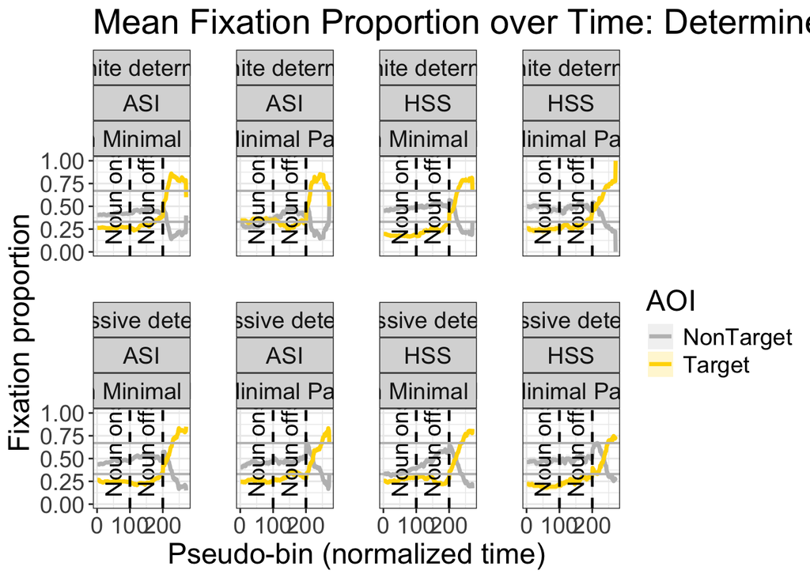

```r
# Combine determiner + noun windows
auc_combined <- bind_rows(
  auc_summary_det,
  auc_summary_noun,
  fix.means.twovar
)

# Make sure grouping vars are factors
auc_combined <- auc_combined %>%
  mutate(
    SpeakerType = as.factor(SpeakerType),
    Determiner = as.factor(Determiner),
    Phonol_Overlap_T = as.factor(Phonol_Overlap_T)
  )

# Plot
auc_plot <- ggplot(
  auc_combined,
  aes(
    x = PBin,
    y = mean_AUC_prop,
    color = AOI,
    group = AOI
  )
) +

  # 8 panels now
  facet_wrap(
    ~ Determiner + SpeakerType + Phonol_Overlap_T,
    ncol = 4,
    labeller = labeller(
      Determiner = c(
        "Definite" = "Definite determiner",
        "Possessive" = "Possessive determiner"
      ),
      SpeakerType = c(
        "1" = "ASI",
        "2" = "HSS"
      ),
      Phonol_Overlap_T = c(
        "Minimal Pair" = "Minimal Pair",
        "NonMinPair" = "Non Minimal Pair"
      )
    )
  ) +

  theme_bw() +

  # Line
  geom_line(linewidth = 1.2) +

  # SE ribbon
  geom_ribbon(
    aes(
      ymin = mean_AUC_prop - se_AUC_prop,
      ymax = mean_AUC_prop + se_AUC_prop,
      fill = AOI
    ),
    alpha = 0.2,
    color = NA
  ) +

  # Vertical line at noun onset
  geom_vline(
    xintercept = N_PBINS,
    linetype = "dashed",
    linewidth = 0.8
  ) +

  # Vertical line at noun offset
  geom_vline(
    xintercept = N_PBINS * 2,
    linetype = "dashed",
    linewidth = 0.8
  ) +

  annotate(
    "text",
    x = N_PBINS,
    y = 0.72,
    label = "Noun onset",
    angle = 90,
    vjust = -0.5,
    size = 5
  ) +

  annotate(
    "text",
    x = N_PBINS * 2,
    y = 0.72,
    label = "Noun offset",
    angle = 90,
    vjust = -0.5,
    size = 5
  ) +

  # Horizontal reference lines
  geom_hline(
    yintercept = c(0.33, 0.67),
    color = "gray75",
    linewidth = 0.7,
    linetype = "solid"
  ) +

  scale_color_manual(
    values = c(
      "Target" = "gold",
      "NonTarget" = "gray"
    )
  ) +

  scale_fill_manual(
    values = c(
      "Target" = "gold",
      "NonTarget" = "gray"
    )
  ) +

  labs(
    title = "Mean Fixation Proportion over Time: Determiner → Noun → Remainder",
    x = "Pseudo-bin (normalized time)",
    y = "Fixation proportion",
    color = "AOI",
    fill = "AOI"
  ) +

  theme(
    text = element_text(size = 18),
    panel.spacing = unit(1, "cm"),
    legend.position = "right"
  )

auc_plot
```

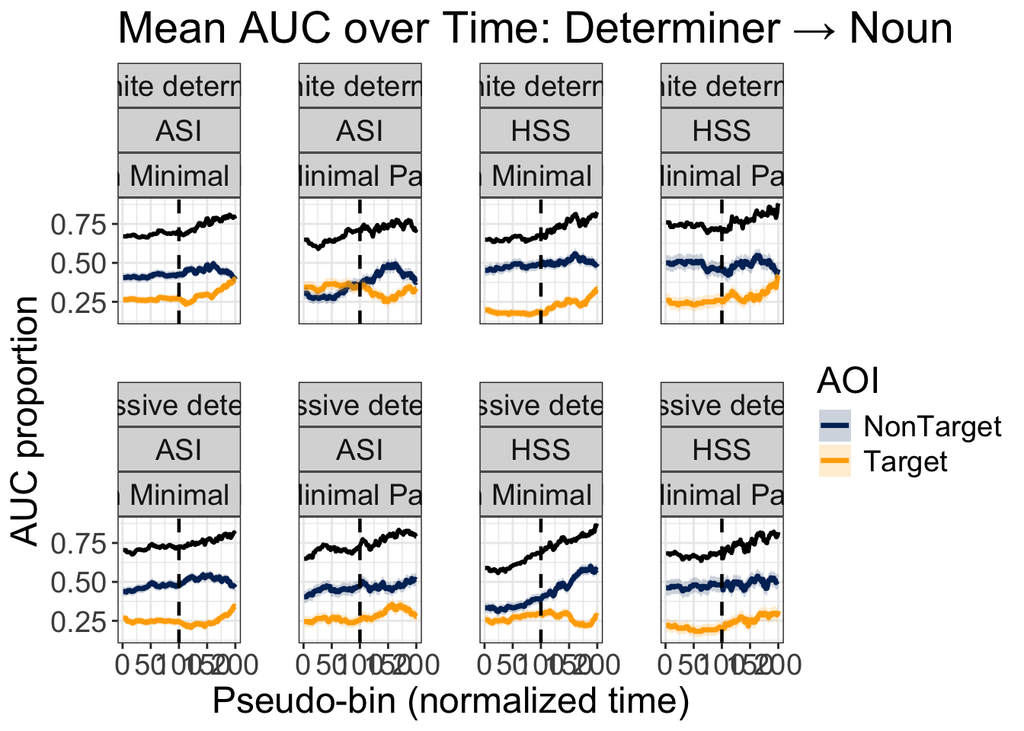

```r
# Combine determiner + noun windows
auc_combined <- bind_rows(
  auc_summary_det,
  auc_summary_noun
)

# Make sure grouping vars are factors
auc_combined <- auc_combined %>%
  mutate(
    SpeakerType = as.factor(SpeakerType),
    Determiner = as.factor(Determiner),
    Phonol_Overlap_T = as.factor(Phonol_Overlap_T)
  )

# Compute Target + NonTarget sum
auc_sum <- auc_combined %>%
  group_by(PBin, Determiner, SpeakerType, Phonol_Overlap_T) %>%
  summarise(
    sum_AUC = sum(mean_AUC_prop),
    .groups = "drop"
  )

# Plot
auc_plot <- ggplot(
  auc_combined,
  aes(
    x = PBin,
    y = mean_AUC_prop,
    color = AOI,
    group = AOI
  )
) +

  # 8 panels
  facet_wrap(
    ~ Determiner + SpeakerType + Phonol_Overlap_T,
    ncol = 4,
    labeller = labeller(
      Determiner = c(
        "Definite" = "Definite determiner",
        "Possessive" = "Possessive determiner"
      ),
      SpeakerType = c(
        "1" = "ASI",
        "2" = "HSS"
      ),
      Phonol_Overlap_T = c(
        "Minimal Pair" = "Minimal Pair",
        "NonMinPair" = "Non Minimal Pair"
      )
    )
  ) +

  theme_bw() +

  # Target / NonTarget lines
  geom_line(linewidth = 1.2) +

  # SE ribbon
  geom_ribbon(
    aes(
      ymin = mean_AUC_prop - se_AUC_prop,
      ymax = mean_AUC_prop + se_AUC_prop,
      fill = AOI
    ),
    alpha = 0.2,
    color = NA
  ) +

  # Sum line (Target + NonTarget)
  geom_line(
    data = auc_sum,
    aes(x = PBin, y = sum_AUC),
    inherit.aes = FALSE,
    color = "black",
    linewidth = 1
  ) +

  # Vertical line at noun onset
  geom_vline(
    xintercept = N_PBINS,
    linetype = "dashed",
    linewidth = 0.8
  ) +

  scale_color_manual(
    values = c(
      "Target" = "#ffac00",
      "NonTarget" = "#002e65"
    )
  ) +

  scale_fill_manual(
    values = c(
      "Target" = "#ffac00",
      "NonTarget" = "#002e65"
    )
  ) +

  labs(
    title = "Mean AUC over Time: Determiner → Noun",
    x = "Pseudo-bin (normalized time)",
    y = "AUC proportion",
    color = "AOI",
    fill = "AOI"
  ) +

  theme(
    text = element_text(size = 18),
    panel.spacing = unit(1, "cm"),
    legend.position = "right"
  )

auc_plot
```

#### Plot the step function for an individual participant-trial

```r
f_example <- step_functions %>%
  filter(Participant == "TA106", AOI == "Target", TOI == "Trial01-def-campesina_0") %>%
  pull(f) %>%
  .[[1]]

t_seq <- seq(-300, 1400, by = 10)

plot(t_seq, f_example(t_seq),
     type = "s", col = "#ffac00", lwd = 2,
     main = "Step Function for TA106 – Trial01-def-campesina_0",
     xlab = "Time (ms, adjusted)", ylab = "Fixation Probability")
```

### Concatenated plot by Determiner Type (from here until the end of section 3, it is generating the older plots before normalization)

##### Merge the non minimal pair values

```r
fix.twovar$Phonol_Overlap <- fix.twovar$Phonol_Overlap_T %>% fct_collapse(NonMinPair = c("First Syll-unstressed", "First Syll-stressed"))

summary(fix.twovar)
head(fix.twovar)
```

##### Compute mean fixation proportions for the two-variable version

```r
fix.means.twovar = Rmisc::summarySE(fix.twovar, measurevar='FixP', groupvars=c('TimeMS_adjusted','SpeakerType', 'AOI', 'Determiner'), na.rm=T)

fix.means.twovar = fix.means.twovar %>% mutate_at(vars(SpeakerType, Determiner), as.factor)

summary(fix.means.twovar)
```

```
##  TimeMS_adjusted SpeakerType        AOI           Determiner        N
##  Min.   :-300    1:924       NonTarget:924   Definite  :924   Min.   :360
##  1st Qu.: 270    2:924       Target   :924   Possessive:924   1st Qu.:360
##  Median : 850                                                 Median :383
##  Mean   : 850                                                 Mean   :383
##  3rd Qu.:1430                                                 3rd Qu.:406
##  Max.   :2000                                                 Max.   :406
##       FixP               sd               se                ci
##  Min.   :0.09722   Min.   :0.2967   Min.   :0.01564   Min.   :0.03075
##  1st Qu.:0.23584   1st Qu.:0.4250   1st Qu.:0.02111   1st Qu.:0.04152
##  Median :0.40074   Median :0.4855   Median :0.02436   Median :0.04788
##  Mean   :0.37361   Mean   :0.4555   Mean   :0.02330   Mean   :0.04582
##  3rd Qu.:0.52218   3rd Qu.:0.4973   3rd Qu.:0.02551   3rd Qu.:0.05017
##  Max.   :0.67222   Max.   :0.5007   Max.   :0.02639   Max.   :0.05190
```

```r
head(fix.means.twovar)
```

```
##   TimeMS_adjusted SpeakerType       AOI Determiner   N      FixP        sd
## 1            -300           1 NonTarget   Definite 360 0.4416667 0.4972767
## 2            -300           1 NonTarget Possessive 360 0.4472222 0.4978987
## 3            -300           1    Target   Definite 360 0.2472222 0.4319974
## 4            -300           1    Target Possessive 360 0.2666667 0.4428321
## 5            -300           2 NonTarget   Definite 406 0.5024631 0.5006108
## 6            -300           2 NonTarget Possessive 406 0.4532020 0.4984193
##           se         ci
## 1 0.02620878 0.05154204
## 2 0.02624157 0.05160650
## 3 0.02276826 0.04477593
## 4 0.02333930 0.04589893
## 5 0.02484490 0.04884106
## 6 0.02473614 0.04862725
```

##### Plot mean fixation proportion vs. time with the two-variable version of the data

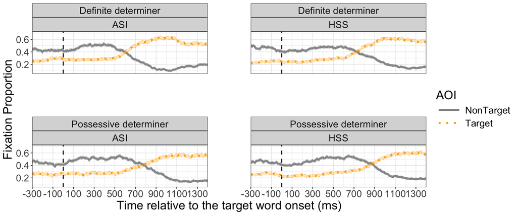

```r
fix.plot.twovar = ggplot() +
  facet_wrap(~Determiner + SpeakerType, ncol=2,
             labeller = labeller(
              Determiner = c(
                "Definite" = "Definite determiner",
                "Possessive" = "Possessive determiner"
              ),
              SpeakerType = c(
                "1" = "ASI",
                "2" = "HSS"
              )
            )
             ) + theme_bw() +
  geom_vline(xintercept = 0, linetype = "dashed", color = "black", linewidth = 0.8) +
  geom_line(data=fix.means.twovar,aes(x=TimeMS_adjusted, y=FixP, group=AOI, colour=AOI, lty=AOI), lwd=1.5) +
  geom_ribbon(data=fix.means.twovar,aes(x=TimeMS_adjusted,ymin=FixP-se,ymax=FixP+se,color=AOI,fill=AOI), linewidth=.2, alpha=.3, lty="dashed", show.legend=F)  +
  labs(y="Fixation Proportion", x="Time relative to the target word onset (ms)") +

  scale_x_continuous(limits=c(-300, 1400),expand=c(0,0),breaks=seq(-300, 1400, 200)) +
  scale_color_manual('AOI', values=c("#969798","#ffac00")) +
  scale_fill_manual('AOI', values=c("#969798","#ffac00")) +
  scale_linetype_manual('AOI', values=c("solid","dotted")) +

  theme(
    text=element_text(size=20),
    legend.key.height=unit(.3,"in"),
    legend.key.width=unit(.6,"in"),
    panel.spacing=unit(1, "in"))

fix.plot.twovar
```

##### Save the plot

```r
ggsave("plots/fixation_plot_twovar.png", width = 20, height = 15, dpi = 300)
```

##### Plot mean fixation proportion to each AOI with standard error, dividing by SpeakerType (ASI and HSS) and Determiner type (Definite and Possessive)

```r
fix.plot = ggplot() +
  facet_wrap(~Determiner + SpeakerType, ncol=2,
             labeller = labeller(
              Determiner = c(
                "Definite" = "Definite determiner",
                "Possessive" = "Possessive determiner"
              ),
              SpeakerType = c(
                "1" = "ASI",
                "2" = "HSS"
              )
            )
             ) + theme_bw() +
  geom_vline(xintercept = 0, linetype = "dashed", color = "black", linewidth = 0.8) +
  geom_line(data=fix.means,aes(x=TimeMS_adjusted, y=FixP, group=AOI, colour=AOI, lty=AOI), lwd=1.5) + # TODO use SE or CI here?
  geom_ribbon(data=fix.means,aes(x=TimeMS_adjusted,ymin=FixP-se,ymax=FixP+se,color=AOI,fill=AOI), linewidth=.2, alpha=.3, lty="dashed", show.legend=F)  +
  labs(y="Fixation Proportion", x="Time relative to the target word onset (ms)") +

  scale_x_continuous(limits=c(-300, 1400),expand=c(0,0),breaks=seq(-300, 1400, 200)) +
  scale_color_manual('AOI', values=c("#af2013","#002e65","#ffac00")) +
  scale_fill_manual('AOI', values=c("#af2013","#002e65","#ffac00")) +
  scale_linetype_manual('AOI', values=c("solid","dotted", "dotdash")) +

  theme(
    text=element_text(size=20),
    legend.key.height=unit(.3,"in"),
    legend.key.width=unit(.6,"in"),
    panel.spacing=unit(1, "in"))

fix.plot
```

##### Save the plot

```r
ggsave("plots/fixation_plot.png", width = 20, height = 15, dpi = 300)
```

##### Plot mean fixation proportion to each AOI with standard error, dividing by SpeakerType (ASI and HSS), Determiner type (Definite and Possessive) and Phonological Overlap (Minimal Pair and Non Minimal Pair)

```r
fix.plot.phonol = ggplot() +
  facet_wrap(~Determiner + SpeakerType + Phonol_Overlap, ncol=4,
             labeller = labeller(
              Determiner = c(
                "Definite" = "Definite determiner",
                "Possessive" = "Possessive determiner"
              ),
              SpeakerType = c(
                "1" = "ASI",
                "2" = "HSS"
              ),
              Phonol_Overlap = c(
                "Minimal Pair" = "Minimal Pair",
                "NonMinPair" = "Non Minimal Pair"
              )
            )
             ) + theme_bw() +
  geom_vline(xintercept = 0, linetype = "dashed", color = "black", linewidth = 0.8) +
  geom_line(data=fix.means.phonol,aes(x=TimeMS_adjusted, y=FixP, group=AOI, colour=AOI, lty=AOI), lwd=1.5) + # TODO use SE or CI here?
  geom_ribbon(data=fix.means.phonol,aes(x=TimeMS_adjusted,ymin=FixP-se,ymax=FixP+se,color=AOI,fill=AOI), linewidth=.2, alpha=.3, lty="dashed", show.legend=F)  +
  labs(y="Fixation Proportion", x="Time relative to the target word onset (ms)") +

  scale_x_continuous(limits=c(-300, 1400),expand=c(0,0),breaks=seq(-300, 1400, 200)) +
  scale_color_manual('AOI', values=c("#af2013","#002e65","#ffac00")) +
  scale_fill_manual('AOI', values=c("#af2013","#002e65","#ffac00")) +
  scale_linetype_manual('AOI', values=c("solid","dotted", "dotdash")) +

  theme(
    text=element_text(size=20),
    legend.key.height=unit(.3,"in"),
    legend.key.width=unit(.6,"in"),
    panel.spacing=unit(1, "in"))

fix.plot.phonol
```

##### Save the plot

```r
ggsave("plots/fixation_plot_phonol.png", width = 40, height = 15, dpi = 300)
```

##### Plot mean fixation proportion to each AOI with standard error, dividing by SpeakerType (ASI and HSS), Determiner type (Definite and Possessive), Phonological Overlap (Minimal Pair and Non Minimal Pair) and GenderMatch (D=T and D=C)

```r
fix.plot.fourgroups = ggplot() +
  facet_wrap(~Determiner + SpeakerType + Phonol_Overlap + GenderMatch, ncol=4,
             labeller = labeller(
              Determiner = c(
                "Definite" = "Definite determiner",
                "Possessive" = "Possessive determiner"
              ),
              SpeakerType = c(
                "1" = "ASI",
                "2" = "HSS"
              ),
              Phonol_Overlap = c(
                "Minimal Pair" = "Minimal Pair",
                "NonMinPair" = "Non Minimal Pair"
              ),
              GenderMatch = c(
                "D=T" = "Distractor = Target",
                "D=C" = "Distractor = Competitor"
              )
            )
             ) + theme_bw() +
  geom_vline(xintercept = 0, linetype = "dashed", color = "black", linewidth = 0.8) +
  geom_line(data=fix.means.fourgroups,aes(x=TimeMS_adjusted, y=FixP, group=AOI, colour=AOI, lty=AOI), lwd=1.5) + # TODO use SE or CI here?
  geom_ribbon(data=fix.means.fourgroups,aes(x=TimeMS_adjusted,ymin=FixP-se,ymax=FixP+se,color=AOI,fill=AOI), linewidth=.2, alpha=.3, lty="dashed", show.legend=F)  +
  labs(y="Fixation Proportion", x="Time relative to the target word onset (ms)") +

  scale_x_continuous(limits=c(-300, 1400),expand=c(0,0),breaks=seq(-300, 1400, 200)) +
  scale_color_manual('AOI', values=c("#af2013","#002e65","#ffac00")) +
  scale_fill_manual('AOI', values=c("#af2013","#002e65","#ffac00")) +
  scale_linetype_manual('AOI', values=c("solid","dotted", "dotdash")) +

  theme(
    text=element_text(size=20),
    legend.key.height=unit(.3,"in"),
    legend.key.width=unit(.6,"in"),
    panel.spacing=unit(1, "in"))

fix.plot.fourgroups
```

##### Save the plot

```r
ggsave("plots/fixation_plot_fourgroups.png", width = 40, height = 30, dpi = 300)
```

##### Plot mean fixation proportion to each AOI with standard error, dividing by SpeakerType (ASI and HSS), Determiner type (Definite and Possessive) and GenderMatch (D=T and D=C)

```r
fix.plot.gendermatch = ggplot() +
  facet_wrap(~Determiner + SpeakerType + GenderMatch, ncol=4,
             labeller = labeller(
              Determiner = c(
                "Definite" = "Definite determiner",
                "Possessive" = "Possessive determiner"
              ),
              SpeakerType = c(
                "1" = "ASI",
                "2" = "HSS"
              ),
              GenderMatch = c(
                "D=T" = "Distractor = Target",
                "D=C" = "Distractor = Competitor"
              )
            )
             ) + theme_bw() +
  geom_vline(xintercept = 0, linetype = "dashed", color = "black", linewidth = 0.8) +
  geom_line(data=fix.means.gendermatch,aes(x=TimeMS_adjusted, y=FixP, group=AOI, colour=AOI, lty=AOI), lwd=1.5) + # TODO use SE or CI here?
  geom_ribbon(data=fix.means.gendermatch,aes(x=TimeMS_adjusted,ymin=FixP-se,ymax=FixP+se,color=AOI,fill=AOI), linewidth=.2, alpha=.3, lty="dashed", show.legend=F)  +
  labs(y="Fixation Proportion", x="Time relative to the target word onset (ms)") +

  scale_x_continuous(limits=c(-300, 1400),expand=c(0,0),breaks=seq(-300, 1400, 200)) +
  scale_color_manual('AOI', values=c("#af2013","#002e65","#ffac00")) +
  scale_fill_manual('AOI', values=c("#af2013","#002e65","#ffac00")) +
  scale_linetype_manual('AOI', values=c("solid","dotted", "dotdash")) +

  theme(
    text=element_text(size=20),
    legend.key.height=unit(.3,"in"),
    legend.key.width=unit(.6,"in"),
    panel.spacing=unit(1, "in"))

fix.plot.gendermatch
```

##### Save the plot

```r
ggsave("plots/fixation_plot_gendermatch.png", width = 40, height = 15, dpi = 300)
```

## 4. DPA

Here we will run a by-participant analysis testing the divergence between the Target and NonTarget AOIs. The conditions are SpeakerType and Determiner.

### Create stratification variables

Previously we selected a time window; now it will be the normalized and concatenated determine and noun portions. Now the pseudo-bin numbers will act like the previous time bin numbers `TimeMS_adjusted` ; FixP will become AUC_prop.

```r
# TODO can't use auc_combined because it takes the average of FixP over all participants and trials
div.dat = auc_combined_raw %>%
  dplyr::mutate(StrataVars=paste(Participant, AOI, PBin, sep='')) %>%
  mutate_at(vars(SpeakerType, StrataVars),as.factor) %>%
  droplevels()

summary(div.dat)
```

```
##   Participant            AOI                              TOI
##  TA105  : 19200   NonTarget:306400   Trial01-def-campesina_0:  7600
##  TA106  : 19200   Target   :306400   Trial02-def-perro_0    :  7600
##  TA107  : 19200                      Trial03-def-pesa_0     :  7600
##  TA108  : 19200                      Trial05-def-coneja_0   :  7600
##  TA109  : 19200                      Trial06-def-brujo_0    :  7600
##  TA110  : 19200                      Trial07-def-ramo_0     :  7600
##  (Other):497600                      (Other)                :567200
##
##
##
##
##
##
##
##
##
##
##
##
##
##
##
##
##
##
##
##
##
##
##
##
##
##
##
##
##
##
##
##
```

[output cut: 31196 more lines]

[output not shown]

```r
head(div.dat)
```

```
## # A tibble: 6 × 16
##   Participant AOI       TOI        f     SpeakerType Determiner Phonol_Overlap_T
##   <fct>       <fct>     <fct>      <lis> <fct>       <fct>      <fct>
## 1 TA105       NonTarget Trial01-d… <fn>  1           Definite   Minimal Pair
## 2 TA105       Target    Trial01-d… <fn>  1           Definite   Minimal Pair
## 3 TA105       NonTarget Trial01-d… <fn>  1           Definite   Minimal Pair
## 4 TA105       Target    Trial01-d… <fn>  1           Definite   Minimal Pair
## 5 TA105       NonTarget Trial01-d… <fn>  1           Definite   Minimal Pair
## 6 TA105       Target    Trial01-d… <fn>  1           Definite   Minimal Pair
## # ℹ 9 more variables: start_anchor <dbl>, end_anchor <dbl>, start <dbl>,
## #   end <dbl>, AUC <dbl>, WindowDur <dbl>, AUC_prop <dbl>, PBin <dbl>,
## #   StrataVars <fct>
```

### Rename columns so we don’t have to change the original DPA code

```r
div.dat <- div.dat %>%
  rename(
    TimeMS_adjusted = PBin,
    FixP = AUC_prop
  )
```

### Create two subsets based on the type of determiner

```r
div.dat.def <- div.dat %>% filter(Determiner == "Definite")
div.dat.pos <- div.dat %>% filter(Determiner == "Possessive")
```

### Define bootstrap functions to compute a divergence point for the target vs. unrelated conditions

#### Bootstrap function using lmer (this should be where the error occurred)

```r
boot_L1L2_lmer = function(original_data, resample_indices){
  dat = original_data[resample_indices, ]

  # a statistical test at each timepoint for each group
  test_g1 = dat %>% # t-test for L1 group
    subset(SpeakerType == 1) %>% group_by(TimeMS_adjusted) %>%
    dplyr::summarise(t = summary(lmer(FixP ~ AOI + (1|Participant)))$coefficients["AOITarget", "t value"])

  test_g2 = dat %>% # t-test for L2 group
    subset(SpeakerType == 2) %>% group_by(TimeMS_adjusted) %>%
    dplyr::summarise(t = summary(lmer(FixP ~ AOI + (1|Participant)))$coefficients["AOITarget", "t value"])

  # return a TRUE/FALSE vector of significant positive t-scores
  # (positive means more looks to the target than unrelated)
  t_g1 = test_g1$t > 1.96
  t_g2 = test_g2$t > 1.96

  # create empty vectors to store onsets
  onset_g1 = onset_g2 = c()

  # find the index of the earliest run of sequential TRUEs; threshold is Nbins
  for (i in 1:(length(t_g2)-Nbins)) {
    onset_g1[i] = sum(t_g1[i:(i+Nbins-1)]) == Nbins
    onset_g2[i] = sum(t_g2[i:(i+Nbins-1)]) == Nbins
  }

  # find the difference between onsets
  delta_g1g2 = which(onset_g2)[1] - which(onset_g1)[1]

  # print
  # note: the bootstrap returns the indices of the respective timepoints, not absolute times.
  # The annotations to the right of each index (e.g. t[,1]) indicate where in the boot object the bootstrapped onset distributions can be found.
  c(delta_g1g2,         # onset difference L1 vs. L2 t[,1]
    which(onset_g1)[1], # onset bin for looks to target L1 t[,2]
    which(onset_g2)[1])  # onset bin for looks to target L2 t[,3]
}
```

#### Run the lmer bootstrap on the two subsets by determiner type

```r
bootres_L1L2_lmer_def = boot::boot(
  data = div.dat.def,  # data set to bootstrap
  statistic = boot_L1L2_lmer,  # bootstrap function
  strata = div.dat.def$StrataVars, # stratification variable
  R = Niter)  # number of iterations

bootres_L1L2_lmer_pos = boot::boot(
  data = div.dat.pos,  # data set to bootstrap
  statistic = boot_L1L2_lmer,  # bootstrap function
  strata = div.dat.pos$StrataVars, # stratification variable
  R = Niter)  # number of iterations

bootres_L1L2_lmer_def
bootres_L1L2_lmer_pos
```

Save the lmer results

```r
save(bootres_L1L2_lmer_def, file="DPA_results.lmer.def.rds")
save(bootres_L1L2_lmer_pos, file="DPA_results.lmer.pos.rds")
```

This ended up yielding mostly NAs due to the small sample size.

Define a function that runs the bootstrap function for all the trials

```r
run_boot_per_trial <- function(toi_id, df, Niter = 100, strata_col = "StrataVars") {
  trial_data <- df %>% filter(TOI == toi_id) %>% droplevels()

  boot_result <- boot::boot(
    data = trial_data,
    statistic = boot_L1L2_glm,  # your divergence function
    strata = trial_data[[strata_col]],
    R = Niter
  )

  # Extract metadata from the first row (assuming Determiner etc. are constant per trial)
  trial_info <- trial_data %>%
    slice(1) %>%
    select(TOI, Determiner, Phonol_Overlap, GenderMatch)  # add more if needed

  list(boot = boot_result, info = trial_info)
}
```

Run the function that runs the bootstrap function

```r
trial_ids <- unique(div.dat$TOI)

# Store both the bootstrap and metadata
boot_trials <- lapply(trial_ids, function(toi) run_boot_per_trial(toi, div.dat, Niter = 100))
names(boot_trials) <- trial_ids
```

Extract divergence values + metadata into a summary dataframe

```r
# Function to extract means and metadata
extract_div_summary <- function(result) {
  bootres <- result$boot
  info <- result$info

  tibble::tibble(
    TOI = info$TOI,
    Determiner = info$Determiner,
    Phonol_Overlap = info$Phonol_Overlap,
    GenderMatch = info$GenderMatchTarget_D,
    ASI_divergence = mean(bootres$t[,2], na.rm = TRUE) * 10 - 10,
    HSS_divergence = mean(bootres$t[,3], na.rm = TRUE) * 10 - 10
  )
}

# Build summary
div_summary_df <- purrr::map_dfr(boot_trials, extract_div_summary)
```

Bootstrap function using glm (generalized linear model)

```r
boot_L1L2_glm = function(original_data, resample_indices){
  dat = original_data[resample_indices, ]

  # a statistical test at each timepoint for each group
  test_g1 = dat %>% # t-test for L1 group
    subset(SpeakerType == 1) %>% group_by(TimeMS_adjusted) %>%
    dplyr::summarise(t = summary(glm(FixP ~ AOI, family = binomial))$coefficients["AOITarget", "z value"])

  test_g2 = dat %>% # t-test for L2 group
    subset(SpeakerType == 2) %>% group_by(TimeMS_adjusted) %>%
    dplyr::summarise(t = summary(glm(FixP ~ AOI, family = binomial))$coefficients["AOITarget", "z value"])

  # return a TRUE/FALSE vector of significant positive t-scores
  # (positive means more looks to the target than unrelated)
  t_g1 = test_g1$t > 1.96
  t_g2 = test_g2$t > 1.96

  # create empty vectors to store onsets
  onset_g1 = onset_g2 = c()

  # find the index of the earliest run of sequential TRUEs; threshold is Nbins
  for (i in 1:(length(t_g2)-Nbins)) {
    onset_g1[i] = sum(t_g1[i:(i+Nbins-1)]) == Nbins
    onset_g2[i] = sum(t_g2[i:(i+Nbins-1)]) == Nbins
  }

  # find the difference between onsets
  delta_g1g2 = which(onset_g2)[1] - which(onset_g1)[1]

  # print
  # note: the bootstrap returns the indices of the respective timepoints, not absolute times.
  # The annotations to the right of each index (e.g. t[,1]) indicate where in the boot object the bootstrapped onset distributions can be found.
  c(delta_g1g2,         # onset difference L1 vs. L2 t[,1]
    which(onset_g1)[1], # onset bin for looks to target L1 t[,2]
    which(onset_g2)[1])  # onset bin for looks to target L2 t[,3]
}
```

Run the glm bootstrap on the two subsets by determiner type

```r
bootres_L1L2_glm_def = boot::boot(
  data = div.dat.def,  # data set to bootstrap
  statistic = boot_L1L2_glm,  # bootstrap function
  strata = div.dat.def$StrataVars, # stratification variable
  R = Niter)  # number of iterations

bootres_L1L2_glm_pos = boot::boot(
  data = div.dat.pos,  # data set to bootstrap
  statistic = boot_L1L2_glm,  # bootstrap function
  strata = div.dat.pos$StrataVars, # stratification variable
  R = Niter)  # number of iterations

bootres_L1L2_glm_def
bootres_L1L2_glm_pos
```

Save the glm results

```r
save(bootres_L1L2_glm_def, file="DPA_results.glm.def.rds")
save(bootres_L1L2_glm_pos, file="DPA_results.glm.pos.rds")
```

##### Extracting and plotting the divergence points

Load the lmer results

```r
load("DPA_results.lmer.def.rds")
load("DPA_results.lmer.pos.rds")
```

Load the glm results

```r
load("DPA_results.glm.def.rds")
load("DPA_results.glm.pos.rds")
```

Define function to extract divergence points and confidence intervals from bootstrapping results

```r
get_divergence_ms <- function(bootres, index) {
  # index = 2 for ASI, 3 for HSS
  mean_bin <- mean(bootres$t[, index], na.rm = TRUE)
  ci_bin <- boot::boot.ci(bootres, index = index, type = "perc")$percent[4:5]

  mean_ms <- (mean_bin - 1) * 10
  ci_ms <- (ci_bin - 1) * 10

  list(mean = mean_ms, ci = ci_ms)
}
```

Run the function on all the results

```r
# Definite determiner
def_asi <- get_divergence_ms(bootres_L1L2_lmer_def, index = 2)
def_hss <- get_divergence_ms(bootres_L1L2_lmer_def, index = 3)

# Possessive determiner
pos_asi <- get_divergence_ms(bootres_L1L2_lmer_pos, index = 2)
pos_hss <- get_divergence_ms(bootres_L1L2_lmer_pos, index = 3)
```

Create dataframe for plotting

```r
div_df <- tibble::tibble(
  Determiner = c("Definite", "Definite", "Possessive", "Possessive"),
  SpeakerType = c("1", "2", "1", "2"),
  TimeMS = c(def_asi$mean, def_hss$mean, pos_asi$mean, pos_hss$mean),
  CI_low = c(def_asi$ci[1], def_hss$ci[1], pos_asi$ci[1], pos_hss$ci[1]),
  CI_high = c(def_asi$ci[2], def_hss$ci[2], pos_asi$ci[2], pos_hss$ci[2])
)

div_df = div_df %>% mutate_at(vars(SpeakerType, Determiner), as.factor)

div_df <- div_df %>%
  mutate(label = paste0(TimeMS, " ms"))
```

Add divergence points and their confidence intervals to the two-variable plots

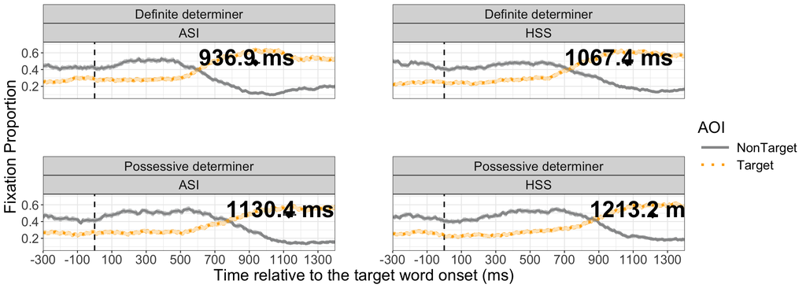

```r
fix.plot.twovar +
  geom_point(data = div_df,
             aes(x = TimeMS, y = 0.48),
             shape = 18, size = 4, color = "black") +
  geom_errorbarh(data = div_df,
                 aes(xmin = CI_low, xmax = CI_high, y = 0.48),
                 height = 0.02, color = "black", linewidth = 0.6) +
  geom_text(data = div_df,
          aes(x = TimeMS - 50, y = 0.55, label = label),
          size = 10, fontface="bold")
```

Save the plots

```r
ggsave("plots/fixation_plot_twovar_divpts.png", width = 20, height = 15, dpi = 300)
```

## 5. Group comparison

We can compute a p-value for the group comparison by creating a bootstrap distribution of the null hypothesis. To do this, we will first pool the original data from both groups, randomly assign group labels, and then estimate a difference in divergence point. We will repeat this many times to obtain a distribution of divergence point that could be expected under the null hypothesis. We will obtain the p-value by calculating the proportion of samples from this null distribution that are larger than the observed difference in divergence point in the empirical data.

Below, we will calculate a p-value for the group comparison (ASI vs. HSS group). We will first define a bootstrap function.

##### Define the bootstrap function for group comparison (only lmer so far)

```r
boot_L1L2_pval = function(original_data, resample_indices){
  dat_resample = original_data[resample_indices, ] # resample the data

  dat = dat_resample %>%
    group_by(Participant, AOI, TimeMS_adjusted) %>%
    transform(SpeakerType=sample(SpeakerType,replace=F)) %>% # randomly assign group labels
    ungroup() #%>%

  # a statistical test at each timepoint for each group
  test_g1 = dat %>% # t-test for L1 group
    subset(SpeakerType == 1) %>% group_by(TimeMS_adjusted) %>%
    dplyr::summarise(t = summary(lmer(FixP ~ AOI + (1|Participant)))$coefficients["AOITarget", "t value"])

  test_g2 = dat %>% # t-test for L2 group
    subset(SpeakerType == 2) %>% group_by(TimeMS_adjusted) %>%
    dplyr::summarise(t = summary(lmer(FixP ~ AOI + (1|Participant)))$coefficients["AOITarget", "t value"])

  # return a TRUE/FALSE vector of significant positive t-scores
  # (positive means more looks to the target than unrelated)
  t_g1 = test_g1$t > 1.96
  t_g2 = test_g2$t > 1.96

  # create empty vectors to store onsets
  onset_g1 = onset_g2 = c()

  # find the index of the earliest run of 4 sequential TRUEs
  for (i in 1:(length(t_g2)-Nbins)) {
    onset_g1[i] = sum(t_g1[i:(i+Nbins-1)]) == Nbins
    onset_g2[i] = sum(t_g2[i:(i+Nbins-1)]) == Nbins
  }

  # find the difference between onsets
  delta_g1g2 = which(onset_g2)[1] - which(onset_g1)[1]

  # print
  delta_g1g2  # onset difference L1 vs. L2 t[,1]
}
```

##### Run the lmer bootstrap on the two subsets by determiner type

```r
bootres_L1L2_pval_def = boot::boot(
  data = div.dat.def,  # data set to bootstrap
  statistic = boot_L1L2_pval,  # bootstrap function
  strata = div.dat.def$StrataVars, # stratification variable
  R = Niter)  # number of iterations

bootres_L1L2_pval_pos = boot::boot(
  data = div.dat.pos,  # data set to bootstrap
  statistic = boot_L1L2_pval,  # bootstrap function
  strata = div.dat.pos$StrataVars, # stratification variable
  R = Niter)  # number of iterations

bootres_L1L2_pval_def
bootres_L1L2_pval_pos
```

##### Save the group comparison results

```r
save(bootres_L1L2_pval, file="DPA_results.pval.def.rds")
save(bootres_L1L2_pval, file="DPA_results.pval.pos.rds")
```

##### If we already have saved results, we can load them.

```r
load("DPA_results.pval.def.rds")
load("DPA_results.pval.pos.rds")
```

##### Compute the p-values

```r
pval.def <- round(mean(bootres_L1L2_pval_def$t[,1]>=bootres_L1L2_lmer_def$t0[1], na.rm=T), 5)
pval.pos <- round(mean(bootres_L1L2_pval_pos$t[,1]>=bootres_L1L2_lmer_pos$t0[1], na.rm=T), 5)

pval.def
pval.pos
```